# Intro to R & Data Visualization

### Glyphs: Your graphical “toppings”

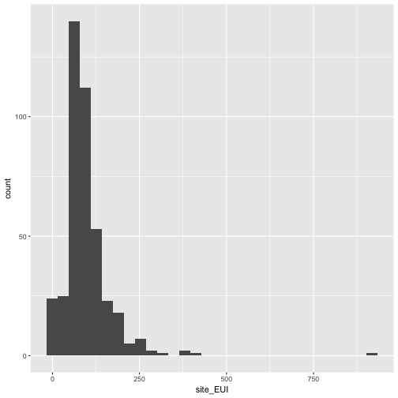

```r
ggplot(data, aes(x=site_EUI)) +
  geom_histogram()
```

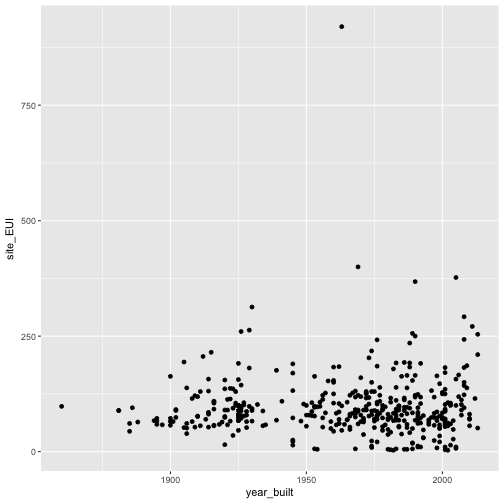

```r
ggplot(data, aes(x=year_built, y=site_EUI)) +
  geom_point()
```

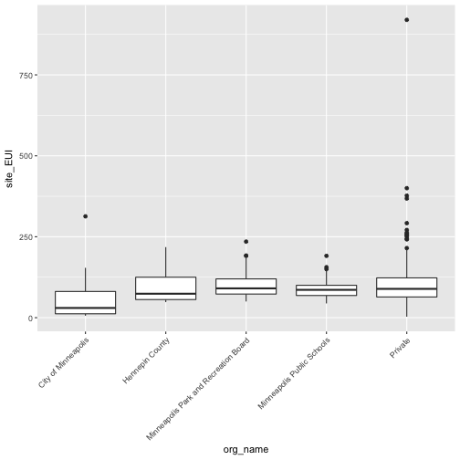

```r
ggplot(data, aes(x=org_name, y=site_EUI)) +
  geom_boxplot() +
  theme(axis.text.x = element_text(angle = 45, hjust = 1))
```

### Know your glyphs!

| Glyph | Aesthetic | Graphic |
| --- | --- | --- |
| geom_histogram() | x (continuous) | histogram |
| geom_density | x (continuous) | density plot (similar to a histogram, but with a curved line instead of a series of bars indicating where data is most densely distributed) |
| geom_bar() | x (categorical) | barchart |
| geom_point() | x (continuous) & y (continuous) | scatterplot |
| geom_boxplot() | x (categorical) & y (continuous) | grouped boxplot |
| geom_violin() | x (categorical) & y (continuous) | grouped violin plot (a combination of a boxplot and a density plot) |

### Facets: Slice up your graphics

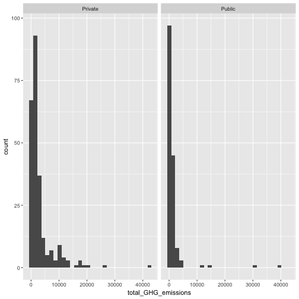

```r
ggplot(data, aes(x=total_GHG_emissions)) +
  geom_histogram() +
  facet_wrap( ~ public_private)
```

### Your turn

Activity: Pick your plot

For each of the questions below, pick a plot type from the ones discussed above (boxplot, histogram, barchart, scatterplot) that you think could best address the question. Then, try to create a plot that you think helps address each question:

- How many of each type of building (“prop_type”) are present in the dataset?
- In approximately what year was the oldest building in the dataset built? The newest building?
- Is there a relationship between the amount of floor area in a building (“floor_area”) and its greenhouse gas emissions (“total_GHG_emissions”)?
- When it comes to site energy use intensity (“site_EUI”), does the dataset tend to have buildings that fall towards the extremes of the spectrum (i.e. many buildings with extremely high or extremely low site energy use intensity measures)? Or do most buildings in the dataset fall somewhere in the middle?
- Are there certain property types (“prop_type”) that seem to have consistently higher energy use intensities (“site_EUI”) than others?

How many of each type of building (“prop_type”) are present in the dataset

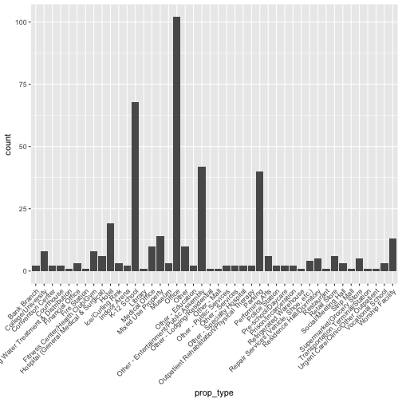

```r
ggplot(data, aes(x=prop_type)) +
  geom_bar() +
  theme(axis.text.x = element_text(angle = 45, hjust = 1))
```

In approximately what year (“year_built”) was the oldest building in the dataset built? The newest building?

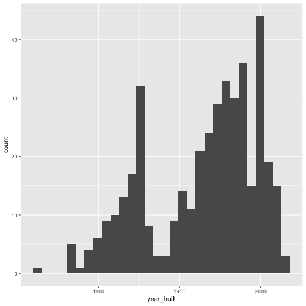

```r
ggplot(data, aes(x=year_built)) +
  geom_histogram()
```

Is there a relationship between the amount of floor area in a building (“floor_area”) and its greenhouse gas emissions (“total_GHG_emissions”)?

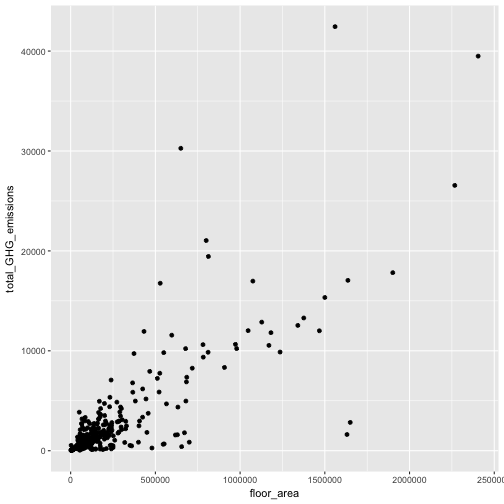

```r
ggplot(data, aes(x=floor_area, y=total_GHG_emissions)) +
  geom_point()
```

When it comes to site energy use intensity (“site_EUI”), does the dataset tend to have buildings that fall towards the extremes of the spectrum (i.e. many buildings with extremely high or extremely low site energy use intensity measures)? Or do most buildings in the dataset fall somewhere in the middle?

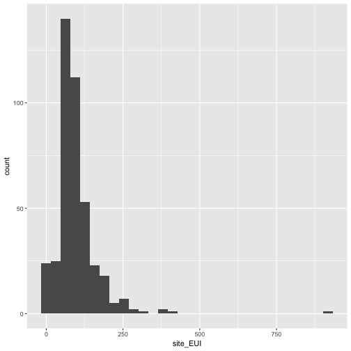

```r
ggplot(data, aes(x=site_EUI)) +
  geom_histogram()
```

Are there certain property types (“prop_type”) that seem to have consistently higher energy use intensities (“site_EUI”) than others?

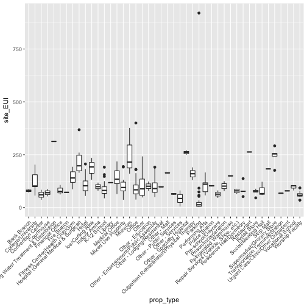

```r
ggplot(data, aes(x=prop_type, y=site_EUI)) +
  geom_boxplot() +
  theme(axis.text.x = element_text(angle = 45, hjust = 1))
```

### But that's not all...

https://linkalis.github.io/r-data-viz-basics-tutorials/

### Questions?

[figure not shown]